[figure not shown]

```julia
Dates.today()
```

```
2017-10-09
```

# Introduction

- Julia is a high-level, high-performance dynamic programming language designed for numerical computing
- The goal is to have an expressive and easy-to-use language without sacrificing performance, and to be able to use the same language in prototyping and in production environments.
- Julia started in 2009 as a research project of a group of MIT students including Jeff Bezanson, Stefan Karpinski and Viral Shah.
- First release in 2012.
- MIT License.
- The current stable version is 0.6.

## Compiler

- Julia has an LLVM-based JIT compiler
- LLVM is a collection of tools for building compilers that provides an intermediate representation capable of carrying out several optimizations. It enables the use of different frontends and backends for generation of different programming languages targeted to different architectures
- Julia code is interpreted and compiled to native machine code.

```julia
f(x) = x * x
```

```
f (generic function with 1 method)
```

```julia
code_llvm(f, (Float64,))
```

```
define double @julia_f_60998(double) #0 !dbg !5 {
top:
  %1 = fmul double %0, %0
  ret double %1
}
```

```julia
code_native(f, (Float64,))
```

```
	.text
Filename: In[2]
	pushq	%rbp
	movq	%rsp, %rbp
Source line: 1
	mulsd	%xmm0, %xmm0
	popq	%rbp
	retq
	nopw	(%rax,%rax)
```

# Features

## Package manager

- Julia has an integrated package manager into the REPL, called Pkg.
- Packages mirror github repositories.

```julia
Pkg.add("IJulia")
```

```
INFO: Package IJulia is already installed
INFO: METADATA is out-of-date — you may not have the latest version of IJulia
INFO: Use `Pkg.update()` to get the latest versions of your packages
```

Some packages:

- DataFrames
- DataFramesMeta
- Distributions
- Distances
- RDatasets

## Integration with other languages

- C and Fortran code can be called via ccall.
- JavaCall
- PyCall
- RCall

### C

```julia
ccall((:clock, "libc"), Int32, ())
```

```
14755061
```

```julia
path = ccall((:getenv, "libc"), Cstring, (Cstring,), "SHELL")
```

```
Cstring(0x00007fff2489b2b0)
```

```julia
unsafe_string(path)
```

```
"/bin/bash"
```

### JavaCall

http://juliainterop.github.io/JavaCall.jl/index.html

```julia
using JavaCall
JavaCall.init(["-Xmx128M"])
```

```
Loaded /usr/lib/jvm/default-java/jre/lib/amd64/server/libjvm.so
```

```julia
jlm = @jimport java.lang.Math
jcall(jlm, "sin", jdouble, (jdouble,), pi/2)
```

```
1.0
```

```julia
j_u_arrays = @jimport java.util.Arrays
jcall(j_u_arrays, "binarySearch", jint, (Array{jint,1}, jint), [10,20,30,40,50,60], 40)
```

```
3
```

```julia
jcall(JString("hello"), "toUpperCase", JString,())
```

```
"HELLO"
```

### PyCall

https://github.com/JuliaPy/PyCall.jl

```julia
using PyCall
@pyimport math
math.sin(math.pi / 4) - sin(pi / 4)
```

```
0.0
```

```julia
@pyimport numpy.random as nr
nr.rand(3,4)
```

```
3×4 Array{Float64,2}:
 0.552391  0.734634  0.608812  0.522554
 0.627791  0.609897  0.69462   0.544767
 0.639515  0.359436  0.616278  0.606977
```

## Integration with the shell

```julia
run(`pwd`)
```

```
/home/german/Documents/julia_lang_talk
```

```julia
run(`ls`)
```

```
extend_test.jl
GenAlg.jl
GenAlgTest.jl
gks.svg
immutability_test.jl
iris.png
julia_lang_talk.odp
Julia_programming_language.html
Julia_programming_language.ipynb
Julia_programming_language.jl
Julia_programming_language.md
Julia_programming_language.pdf
latex
module_test
outline.txt
```

## Vectors and matrices

```julia
x = rand(3,4)
```

```
3×4 Array{Float64,2}:
 0.461464  0.461835    0.429575  0.843564
 0.879913  0.99466     0.483259  0.477984
 0.371927  0.00553818  0.454886  0.649505
```

### Indexing

```julia
x[1,:]
```

```
4-element Array{Float64,1}:
 0.461464
 0.461835
 0.429575
 0.843564
```

```julia
x[:,1]
```

```
3-element Array{Float64,1}:
 0.461464
 0.879913
 0.371927
```

```julia
x[1,1]
```

```
0.4614636345201051
```

- Indexing (on the right side of an assignment ) makes a copy of the original array
- Assignment **does not** make a copy

```julia
y = x
```

```
3×4 Array{Float64,2}:
 0.461464  0.461835    0.429575  0.843564
 0.879913  0.99466     0.483259  0.477984
 0.371927  0.00553818  0.454886  0.649505
```

```julia
x[1,:] = zeros(1,4)
```

```
1×4 Array{Float64,2}:
 0.0  0.0  0.0  0.0
```

```julia
x
```

```
3×4 Array{Float64,2}:
 0.0       0.0         0.0       0.0
 0.879913  0.99466     0.483259  0.477984
 0.371927  0.00553818  0.454886  0.649505
```

```julia
y
```

```
3×4 Array{Float64,2}:
 0.0       0.0         0.0       0.0
 0.879913  0.99466     0.483259  0.477984
 0.371927  0.00553818  0.454886  0.649505
```

```julia
z = x[2,:]
```

```
4-element Array{Float64,1}:
 0.879913
 0.99466
 0.483259
 0.477984
```

```julia
x = zeros(3,4)
```

```
3×4 Array{Float64,2}:
 0.0  0.0  0.0  0.0
 0.0  0.0  0.0  0.0
 0.0  0.0  0.0  0.0
```

```julia
z
```

```
4-element Array{Float64,1}:
 0.879913
 0.99466
 0.483259
 0.477984
```

```julia
x
```

```
3×4 Array{Float64,2}:
 0.0  0.0  0.0  0.0
 0.0  0.0  0.0  0.0
 0.0  0.0  0.0  0.0
```

```julia
z2 = x[:,:]
```

```
3×4 Array{Float64,2}:
 0.0  0.0  0.0  0.0
 0.0  0.0  0.0  0.0
 0.0  0.0  0.0  0.0
```

```julia
x[1,:] = 3
```

```
3
```

```julia
x
```

```
3×4 Array{Float64,2}:
 3.0  3.0  3.0  3.0
 0.0  0.0  0.0  0.0
 0.0  0.0  0.0  0.0
```

```julia
z2
```

```
3×4 Array{Float64,2}:
 0.0  0.0  0.0  0.0
 0.0  0.0  0.0  0.0
 0.0  0.0  0.0  0.0
```

### Linear algebra operations

```julia
x = rand(4,3)
```

```
4×3 Array{Float64,2}:
 0.422571  0.114252  0.967498
 0.266194  0.27021   0.286553
 0.532872  0.508771  0.867359
 0.61544   0.875569  0.251664
```

```julia
x'
```

```
3×4 Array{Float64,2}:
 0.422571  0.266194  0.532872  0.61544
 0.114252  0.27021   0.508771  0.875569
 0.967498  0.286553  0.867359  0.251664
```

```julia
x2 = x * x'
```

```
4×4 Array{Float64,2}:
 1.12767   0.420597  1.12247   0.603587
 0.420597  0.225985  0.527866  0.472529
 1.12247   0.527866  1.29511   0.991698
 0.603587  0.472529  0.991698  1.20872
```

```julia
det(x2)
```

```
2.4474627419440733e-19
```

```julia
pinv(x2)
```

```
4×4 Array{Float64,2}:
   94.4626   34.0729  -132.893    48.4963
   34.0729   12.4462   -48.4297   18.0583
 -132.893   -48.4297   189.311   -70.0265
   48.4963   18.0583   -70.0265   26.9472
```

```julia
row = rand(4)
```

```
4-element Array{Float64,1}:
 0.819061
 0.454094
 0.943337
 0.383105
```

```julia
row'
```

```
1×4 RowVector{Float64,Array{Float64,1}}:
 0.819061  0.454094  0.943337  0.383105
```

```julia
row' * row
```

```
1.91371688275563
```

### Horizontal and vertical concatenation

```julia
[1 2 3 4]
```

```
1×4 Array{Int64,2}:
 1  2  3  4
```

```julia
[1 ; 2 ; 3 ; 4]
```

```
4-element Array{Int64,1}:
 1
 2
 3
 4
```

```julia
[1 2 ; 3 4]
```

```
2×2 Array{Int64,2}:
 1  2
 3  4
```

```julia
[1, 2, 3, 4]
```

```
4-element Array{Int64,1}:
 1
 2
 3
 4
```

```julia
[[1,2] [3,4]]
```

```
2×2 Array{Int64,2}:
 1  3
 2  4
```

```julia
[[1,2] ; [3,4]]
```

```
4-element Array{Int64,1}:
 1
 2
 3
 4
```

```julia
sum([[1,2] , [3,4]])
```

```
2-element Array{Int64,1}:
 4
 6
```

### Vectorized operations

```julia
x = rand(4,3)
```

```
4×3 Array{Float64,2}:
 0.337631  0.860092  0.373924
 0.802954  0.921814  0.0248137
 0.290755  0.923641  0.753294
 0.173192  0.337433  0.946924
```

```julia
sum(x)
```

```
6.74646652856489
```

```julia
sum(x,1)
```

```
1×3 Array{Float64,2}:
 1.60453  3.04298  2.09896
```

```julia
sum(x,2)
```

```
4×1 Array{Float64,2}:
 1.57165
 1.74958
 1.96769
 1.45755
```

```julia
x^2
```

```
DimensionMismatch("A has dimensions (4,3) but B has dimensions (4,3)")

Stacktrace:
 [1] gemm_wrapper!(::Array{Float64,2}, ::Char, ::Char, ::Array{Float64,2}, ::Array{Float64,2}) at ./linalg/matmul.jl:345
 [2] power_by_squaring(::Array{Float64,2}, ::Int64) at ./intfuncs.jl:166
 [3] ^ at ./linalg/dense.jl:332 [inlined]
 [4] literal_pow(::Base.#^, ::Array{Float64,2}, ::Type{Val{2}}) at ./intfuncs.jl:205
 [5] include_string(::String, ::String) at ./loading.jl:515
```

```julia
x.^2
```

```
4×3 Array{Float64,2}:
 0.113995   0.739758  0.139819
 0.644735   0.84974   0.000615722
 0.0845383  0.853112  0.567452
 0.0299953  0.113861  0.896665
```

```julia
x .> 0.5
```

```
4×3 BitArray{2}:
 false   true  false
  true   true  false
 false   true   true
 false  false   true
```

#### Boolean indexing

```julia
x[x .> 0.5]
```

```
6-element Array{Float64,1}:
 0.802954
 0.860092
 0.921814
 0.923641
 0.753294
 0.946924
```

# Type system

https://docs.julialang.org/en/stable/manual/types/

- In Julia everything is a value that can be stored in variables and passed around to functions. All values have a type. Even functions and types are values, and have their own type.

```julia
typeof(3)
```

```
Int64
```

```julia
t = typeof(3)
typeof(t)
```

```
DataType
```

Julia has different kinds of types:

- Primitive types, like Int32, Int64, Bool, String Float64 and so on.
- Abstract types
- Composite types, both mutable and immutable
- Tuple types
- Union types
- UnionAll types

## Types and Inheritance

- Composite types are like records or classes in other languages, and they can hold values of different types. Immutable types are declared with the "struct" keyword and mutable types with the "mutable struct" keyword.
- In Julia, types form a hierarchy in which only the leaf nodes represent concrete types. There is no field inheritance as in object-oriented languages.
- "Interfaces" are defined by collections of functions that can be implemented for a certain type to make it work in a certain way. For example, it a type implements functions "start", "next" and "done" it can be used as in iterator, for a example in a for-each construct.
- "Any" is the root of the type hierarchy
- Types can be parameterized, to enable generic programming.

## Functions

- Operators are just functions with special syntax.
- Given a function call, Julia looks at compile-time for the most specific function definition available for the given argument types (More about this in section about Multiple dispatch).
- mutable structures like arrays are passed-by-sharing, which means they are not copied and changes in the callee affect the caller. Immutable values like integers cannot be modified, so they are passed-by-copy.

## Higher-order functions and anonymous functions

```julia
x = collect(1:10)
```

```
10-element Array{Int64,1}:
  1
  2
  3
  4
  5
  6
  7
  8
  9
 10
```

```julia
map(e -> e ^ 2, x)
```

```
10-element Array{Int64,1}:
   1
   4
   9
  16
  25
  36
  49
  64
  81
 100
```

```julia
filter(e -> e % 2 == 0, x)
```

```
5-element Array{Int64,1}:
  2
  4
  6
  8
 10
```

```julia
foldl((t,e) -> t + e, 0, x)
```

```
55
```

## Union types and UnionAll types

A union type can contain values from either of its base types. It acts as a supertype of the types involved.

```julia
intOrString(x::Union{Int, String}) = println(x)

intOrString(3) # this works
intOrString("a") # this works
intOrString(true) # this fails
```

```
3
a
```

```
MethodError: no method matching intOrString(::Bool)
Closest candidates are:
  intOrString(::Union{Int64, String}) at In[62]:1

Stacktrace:
 [1] include_string(::String, ::String) at ./loading.jl:515
```

An UnionAll type represents a set of types that have a certain property.

- For example, Vector{Int}, which represents one-dimensional integer vectors is just an alias for Array{Int, 1}.
- "Array{Int, 1}" in turn is subtype of "Array{Int, N} where N", which encloses integer arrays of any dimensions.
- "Array{Int, N} where N" is in turn subtype of "Array{T, N} where N where T", encloses arrays of any type and of any dimensions.

UnionAll types enable us to put restriction over the types a parametric type can accept, i.e., they enable us to implement lower and upper type bounds. For example:

```julia
function sumReal(x::Array{T, N} where T <: Real where N)
    sum(x)
end

sumReal([1,2,3]) # this works
sumReal([1.0,2.0,3.0]) #this works
sumReal([1im, 2im, 3im]) #this fails
```

```
MethodError: no method matching sumReal(::Array{Complex{Int64},1})
Closest candidates are:
  sumReal(::Array{T,N} where T<:Real where N) at In[63]:2

Stacktrace:
 [1] include_string(::String, ::String) at ./loading.jl:515
```

## Tuples, Sets and Dicts

```julia
t = (2,true)
println(typeof(t))
(a,b) = t
println(a)
println(b)
```

```
Tuple{Int64,Bool}
2
true
```

```julia
s = Set([1,2,3])
6 in s
```

```
false
```

```julia
d = Dict(2 => "a", 3 => "b", 4 => "c")
println(typeof(d))
println((2 => "a") in d)
haskey(d, 1)
get(d, 9, "not found")
```

```
Dict{Int64,String}
true
```

```
"not found"
```

## Example

- Type definitions
- Function declarations
- Parametric types
- Multiple dispatch (explained later)
- Method extension
- String interpolation

```julia
abstract type Tree{T} end
struct Node{T} <: Tree{T}
    left::Tree{T}
    right::Tree{T}
end
struct Leaf{T} <: Tree{T}
    value::T
end
struct Empty{T} <: Tree{T} end

#Type parameter can be omitted if it is not necessary
height(t::Node) = max(height(t.left), height(t.right)) + 1
height(t::Leaf) = 0
height(t::Empty) = -1

#Method size from Base has to be explicitly imported in order to be extended.
Base.size(t::Node) = size(t.left) + size(t.right) + 1
Base.size(t::Leaf) = 1
Base.size(t::Empty) = 0

# Note that functions can be declared either in short-form for one-line expressions or in long-form.
show(t::Tree) = show(t, 0)
show(t::Leaf, margin::Int) = println("$(repeat(" ", margin))Leaf($(t.value))")
show(t::Empty, margin::Int) = println("$(repeat(" ", margin))-")
function show(t::Node, margin::Int)
    println("$(repeat(" ", margin))Node")
    show(t.left, margin + 4)
    show(t.right, margin + 4)
end


tree = Node(Node(Leaf(1), Leaf(2)), Node(Leaf(3), Leaf(4)))
println(typeof(tree))
println("height = $(height(tree))")
println("size = $(size(tree))")
show(tree)
```

```
Node{Int64}
height = 2
size = 7
Node
    Node
        Leaf(1)
        Leaf(2)
    Node
        Leaf(3)
        Leaf(4)
```

## Immutability

From the docs (https://docs.julialang.org/en/stable/manual/types/#Mutable-Composite-Types-1):

- *An object with an immutable type is passed around (both in assignment statements and in function calls) by copying, whereas a mutable type is passed around by reference.*
- *It is not permitted to modify the fields of a composite immutable type.*
- Immutable values can be stored more efficiently and are easier to reason about. Immutability is the default behaviour of user-defined types, by using the "struct" keyword.
- As a rule of thumb, if two objects of the same type with the same values on the same fields should be considered identical, then the type should be defined as immutable. Otherwise, if the values should be considered different objects because they can change independently, then the type should be defined as mutable.
- A variable pointing to an immutable object can point to a different object at any time. Immutability means that the object itself cannot change.

Example:

```julia
struct T
    x::Int
    y::Bool
end

println(T(2, true) === T(2, true))
t = T(2, true)
t = T(3, false) #points to a different object
t.x = 6 # this throws an error
```

```
true
```

```
type T is immutable

Stacktrace:
 [1] include_string(::String, ::String) at ./loading.jl:515
```

```julia
struct T2
    x::Int
    y::Bool
    z::Vector{Int} # an immutable type with a mutable field
end

println(T2(2, true, [1,2,3]) === T2(2, true, [1,2,3])) # this no longer holds because field z is mutable
t = T2(2, true, [1,2,3])
t.z[3] = 9 # the mutable field can be modified
println(t)
t.z = [3,4,5] # but the field cannot point to a different object, because T2 is immutable.
```

```
false
T2(2, true, [1, 2, 9])
```

```
type T2 is immutable

Stacktrace:
 [1] include_string(::String, ::String) at ./loading.jl:515
```

```julia
t.z[:] = [3,4,5] # this works because it is modifying the object without changing the reference
t
```

```
T2(2, true, [3, 4, 5])
```

## Multiple dispatch

```julia
%%python
```

The analogue of IPython's `%%python ...code...` in Julia can be constructed by first evaluating

```
macro python_str(s) open(`python`,"w",STDOUT) do io; print(io, s); end; end
```

to define the `python"...."` [string macro](http://docs.julialang.org/en/latest/manual/strings/#non-standard-string-literals) in Julia. Subsequently, you can simply do:

```
python"""
...code...
"""
```

to evaluate the code in `python` (outputting to `STDOUT`).

```julia
macro python_str(s) open(`python`,"w",STDOUT) do io; print(io, s); end; end
```

```
@python_str (macro with 1 method)
```

- In single-dispatch languages, which method is invoked depends on the runtime type of the object that owns the method.

```julia
python"""
class A:
    def f(self):
        print("A")

class B:
    def f(self):
        print("B")

xs = [A(), B()]
for x in xs:
    x.f()
"""
```

```
A
B
```

- Double-dispatch (resolving the method based on two objects' types) is simulated by using several method calls

```julia
python"""
class A:
    def f(self):
        print("A")

    def doSomething(self, other):
        other.doSomethingWithA(self)

    def doSomethingWithA(self, other):
        print("AA")

    def doSomethingWithB(self, other):
        print("AB")

class B:
    def f(self):
        print("B")

    def doSomething(self, other):
        other.doSomethingWithB(self)

    def doSomethingWithA(self, other):
        print("BA")

    def doSomethingWithB(self, other):
        print("BB")

xs = [A(), B()]
for x in xs:
    for y in xs:
        x.doSomething(y)
"""
```

```
AA
BA
AB
BB
```

- Multiple dispatch consists in determining the correct method to invoked based on the types of all the arguments involved, not just the first one.
- In Julia, objects (values), **do not** own the methods (values) that operate on them.
- Instead, several functions with the same name provide different behaviors for different types. These different implementations are called "methods" of the same "function". This is analogous to the object-oriented concept of messages (a request for an operation) and methods (a concrete implementation of such request).
- Different methods for the same function can be examined by using the "methods" function

```julia
?methods
```

```
search: methods methodswith listmethods method_exists Method MethodTable
```

```
methods(f, [types])
```

Returns the method table for `f`.

If `types` is specified, returns an array of methods whose types match.

```julia
methods(size)
```

97 methods for generic function **size**:

- size(c::**Char**) at [char.jl:13](https://github.com/JuliaLang/julia/tree/903644385b91ed8d95e5e3a5716c089dd1f1b08a/base/char.jl#L13)

- size(c::**Char**, d) at [char.jl:14](https://github.com/JuliaLang/julia/tree/903644385b91ed8d95e5e3a5716c089dd1f1b08a/base/char.jl#L14)

- size(B::**BitArray{1}**) at [bitarray.jl:62](https://github.com/JuliaLang/julia/tree/903644385b91ed8d95e5e3a5716c089dd1f1b08a/base/bitarray.jl#L62)

- size(B::**BitArray{1}**, d) at [bitarray.jl:66](https://github.com/JuliaLang/julia/tree/903644385b91ed8d95e5e3a5716c089dd1f1b08a/base/bitarray.jl#L66)

- size(itr::**Base.AsyncGenerator**) at [asyncmap.jl:412](https://github.com/JuliaLang/julia/tree/903644385b91ed8d95e5e3a5716c089dd1f1b08a/base/asyncmap.jl#L412)

- size(zmsg::**ZMQ.Message**) at [/home/german/.julia/v0.6/ZMQ/src/ZMQ.jl:423](https://github.com/JuliaInterop/ZMQ.jl/tree/581a9d6f1890973c168af89d87ebeeebc0d2881b//src/ZMQ.jl#L423)

- size(b::**PyCall.PyBuffer**) at [/home/german/.julia/v0.6/PyCall/src/pybuffer.jl:61](https://github.com/JuliaPy/PyCall.jl/tree/0550f890c86878375f74821a459da41e7cc943f6//src/pybuffer.jl#L61)

- size(b::**PyCall.PyBuffer**, d::**Integer**) at [/home/german/.julia/v0.6/PyCall/src/pybuffer.jl:67](https://github.com/JuliaPy/PyCall.jl/tree/0550f890c86878375f74821a459da41e7cc943f6//src/pybuffer.jl#L67)

- size(g::**Base.Generator**) at [generator.jl:114](https://github.com/JuliaLang/julia/tree/903644385b91ed8d95e5e3a5716c089dd1f1b08a/base/generator.jl#L114)

- size(t::**Tuple**, d) at [tuple.jl:20](https://github.com/JuliaLang/julia/tree/903644385b91ed8d95e5e3a5716c089dd1f1b08a/base/tuple.jl#L20)

- size(S::**Base.Slice**) at [indices.jl:241](https://github.com/JuliaLang/julia/tree/903644385b91ed8d95e5e3a5716c089dd1f1b08a/base/indices.jl#L241)

- size(r::**Range**) at [range.jl:335](https://github.com/JuliaLang/julia/tree/903644385b91ed8d95e5e3a5716c089dd1f1b08a/base/range.jl#L335)

- size(x::**Number**) at [number.jl:24](https://github.com/JuliaLang/julia/tree/903644385b91ed8d95e5e3a5716c089dd1f1b08a/base/number.jl#L24)

- size(x::**Number**, d) at [number.jl:25](https://github.com/JuliaLang/julia/tree/903644385b91ed8d95e5e3a5716c089dd1f1b08a/base/number.jl#L25)

- size(a::**Array{T,1} where T**) at [array.jl:86](https://github.com/JuliaLang/julia/tree/903644385b91ed8d95e5e3a5716c089dd1f1b08a/base/array.jl#L86)

- size(a::**Array{T,2} where T**) at [array.jl:87](https://github.com/JuliaLang/julia/tree/903644385b91ed8d95e5e3a5716c089dd1f1b08a/base/array.jl#L87)

- size(a::**Array**) at [array.jl:88](https://github.com/JuliaLang/julia/tree/903644385b91ed8d95e5e3a5716c089dd1f1b08a/base/array.jl#L88)

- size(a::**Array**, d) at [array.jl:85](https://github.com/JuliaLang/julia/tree/903644385b91ed8d95e5e3a5716c089dd1f1b08a/base/array.jl#L85)

- size(V::**SubArray**) at [subarray.jl:56](https://github.com/JuliaLang/julia/tree/903644385b91ed8d95e5e3a5716c089dd1f1b08a/base/subarray.jl#L56)

- size(A::**Base.ReshapedArray**) at [reshapedarray.jl:166](https://github.com/JuliaLang/julia/tree/903644385b91ed8d95e5e3a5716c089dd1f1b08a/base/reshapedarray.jl#L166)

- size(B::**BitArray**) at [bitarray.jl:63](https://github.com/JuliaLang/julia/tree/903644385b91ed8d95e5e3a5716c089dd1f1b08a/base/bitarray.jl#L63)

- size(L::**Base.LogicalIndex**) at [multidimensional.jl:329](https://github.com/JuliaLang/julia/tree/903644385b91ed8d95e5e3a5716c089dd1f1b08a/base/multidimensional.jl#L329)

- size*{T, N, perm}*(A::**PermutedDimsArray{T,N,perm,iperm,AA} where AA<:AbstractArray where iperm**) at [permuteddimsarray.jl:49](https://github.com/JuliaLang/julia/tree/903644385b91ed8d95e5e3a5716c089dd1f1b08a/base/permuteddimsarray.jl#L49)

- size(a::**ConjArray**) at [linalg/conjarray.jl:44](https://github.com/JuliaLang/julia/tree/903644385b91ed8d95e5e3a5716c089dd1f1b08a/base/linalg/conjarray.jl#L44)

- size(rowvec::**RowVector**) at [linalg/rowvector.jl:110](https://github.com/JuliaLang/julia/tree/903644385b91ed8d95e5e3a5716c089dd1f1b08a/base/linalg/rowvector.jl#L110)

- size(rowvec::**RowVector**, d) at [linalg/rowvector.jl:111](https://github.com/JuliaLang/julia/tree/903644385b91ed8d95e5e3a5716c089dd1f1b08a/base/linalg/rowvector.jl#L111)

- size(A::**SymTridiagonal**) at [linalg/tridiag.jl:85](https://github.com/JuliaLang/julia/tree/903644385b91ed8d95e5e3a5716c089dd1f1b08a/base/linalg/tridiag.jl#L85)

- size(A::**SymTridiagonal**, d::**Integer**) at [linalg/tridiag.jl:87](https://github.com/JuliaLang/julia/tree/903644385b91ed8d95e5e3a5716c089dd1f1b08a/base/linalg/tridiag.jl#L87)

- size(M::**Tridiagonal**) at [linalg/tridiag.jl:477](https://github.com/JuliaLang/julia/tree/903644385b91ed8d95e5e3a5716c089dd1f1b08a/base/linalg/tridiag.jl#L477)

- size(M::**Tridiagonal**, d::**Integer**) at [linalg/tridiag.jl:479](https://github.com/JuliaLang/julia/tree/903644385b91ed8d95e5e3a5716c089dd1f1b08a/base/linalg/tridiag.jl#L479)

- size(A::**LowerTriangular**) at [linalg/triangular.jl:22](https://github.com/JuliaLang/julia/tree/903644385b91ed8d95e5e3a5716c089dd1f1b08a/base/linalg/triangular.jl#L22)

- size(A::**LowerTriangular**, d) at [linalg/triangular.jl:21](https://github.com/JuliaLang/julia/tree/903644385b91ed8d95e5e3a5716c089dd1f1b08a/base/linalg/triangular.jl#L21)

- size(A::**Base.LinAlg.UnitLowerTriangular**) at [linalg/triangular.jl:22](https://github.com/JuliaLang/julia/tree/903644385b91ed8d95e5e3a5716c089dd1f1b08a/base/linalg/triangular.jl#L22)

- size(A::**Base.LinAlg.UnitLowerTriangular**, d) at [linalg/triangular.jl:21](https://github.com/JuliaLang/julia/tree/903644385b91ed8d95e5e3a5716c089dd1f1b08a/base/linalg/triangular.jl#L21)

- size(A::**UpperTriangular**) at [linalg/triangular.jl:22](https://github.com/JuliaLang/julia/tree/903644385b91ed8d95e5e3a5716c089dd1f1b08a/base/linalg/triangular.jl#L22)

- size(A::**UpperTriangular**, d) at [linalg/triangular.jl:21](https://github.com/JuliaLang/julia/tree/903644385b91ed8d95e5e3a5716c089dd1f1b08a/base/linalg/triangular.jl#L21)

- size(A::**Base.LinAlg.UnitUpperTriangular**) at [linalg/triangular.jl:22](https://github.com/JuliaLang/julia/tree/903644385b91ed8d95e5e3a5716c089dd1f1b08a/base/linalg/triangular.jl#L22)

- size(A::**Base.LinAlg.UnitUpperTriangular**, d) at [linalg/triangular.jl:21](https://github.com/JuliaLang/julia/tree/903644385b91ed8d95e5e3a5716c089dd1f1b08a/base/linalg/triangular.jl#L21)

- size(A::**Union{Base.LinAlg.QRCompactWYQ, Base.LinAlg.QRPackedQ}**) at [linalg/qr.jl:486](https://github.com/JuliaLang/julia/tree/903644385b91ed8d95e5e3a5716c089dd1f1b08a/base/linalg/qr.jl#L486)

- size(A::**Union{Base.LinAlg.QRCompactWYQ, Base.LinAlg.QRPackedQ}**, dim::**Integer**) at [linalg/qr.jl:485](https://github.com/JuliaLang/julia/tree/903644385b91ed8d95e5e3a5716c089dd1f1b08a/base/linalg/qr.jl#L485)

- size(A::**Base.LinAlg.HessenbergQ**) at [linalg/hessenberg.jl:64](https://github.com/JuliaLang/julia/tree/903644385b91ed8d95e5e3a5716c089dd1f1b08a/base/linalg/hessenberg.jl#L64)

- size(A::**Base.LinAlg.HessenbergQ**, d) at [linalg/hessenberg.jl:63](https://github.com/JuliaLang/julia/tree/903644385b91ed8d95e5e3a5716c089dd1f1b08a/base/linalg/hessenberg.jl#L63)

- size(A::**Base.LinAlg.LQPackedQ**) at [linalg/lq.jl:119](https://github.com/JuliaLang/julia/tree/903644385b91ed8d95e5e3a5716c089dd1f1b08a/base/linalg/lq.jl#L119)

- size(A::**Base.LinAlg.LQPackedQ**, dim::**Integer**) at [linalg/lq.jl:110](https://github.com/JuliaLang/julia/tree/903644385b91ed8d95e5e3a5716c089dd1f1b08a/base/linalg/lq.jl#L110)

- size(A::**Union{Hermitian{T,S}, Symmetric{T,S}} where S where T**) at [linalg/symmetric.jl:107](https://github.com/JuliaLang/julia/tree/903644385b91ed8d95e5e3a5716c089dd1f1b08a/base/linalg/symmetric.jl#L107)

- size(A::**Union{Hermitian{T,S}, Symmetric{T,S}} where S where T**, d) at [linalg/symmetric.jl:106](https://github.com/JuliaLang/julia/tree/903644385b91ed8d95e5e3a5716c089dd1f1b08a/base/linalg/symmetric.jl#L106)

- size(D::**Diagonal**) at [linalg/diagonal.jl:64](https://github.com/JuliaLang/julia/tree/903644385b91ed8d95e5e3a5716c089dd1f1b08a/base/linalg/diagonal.jl#L64)

- size(D::**Diagonal**, d::**Integer**) at [linalg/diagonal.jl:67](https://github.com/JuliaLang/julia/tree/903644385b91ed8d95e5e3a5716c089dd1f1b08a/base/linalg/diagonal.jl#L67)

- size(M::**Bidiagonal**) at [linalg/bidiag.jl:248](https://github.com/JuliaLang/julia/tree/903644385b91ed8d95e5e3a5716c089dd1f1b08a/base/linalg/bidiag.jl#L248)

- size(M::**Bidiagonal**, d::**Integer**) at [linalg/bidiag.jl:250](https://github.com/JuliaLang/julia/tree/903644385b91ed8d95e5e3a5716c089dd1f1b08a/base/linalg/bidiag.jl#L250)

- size(s::**Base.LinAlg.SVDOperator**) at [linalg/arnoldi.jl:323](https://github.com/JuliaLang/julia/tree/903644385b91ed8d95e5e3a5716c089dd1f1b08a/base/linalg/arnoldi.jl#L323)

- size(a::**Base.DFT.FFTW.FakeArray**) at [fft/FFTW.jl:75](https://github.com/JuliaLang/julia/tree/903644385b91ed8d95e5e3a5716c089dd1f1b08a/base/fft/FFTW.jl#L75)

- size(S::**SparseMatrixCSC**) at [sparse/sparsematrix.jl:28](https://github.com/JuliaLang/julia/tree/903644385b91ed8d95e5e3a5716c089dd1f1b08a/base/sparse/sparsematrix.jl#L28)

- size(x::**SparseVector**) at [sparse/sparsevector.jl:31](https://github.com/JuliaLang/julia/tree/903644385b91ed8d95e5e3a5716c089dd1f1b08a/base/sparse/sparsevector.jl#L31)

- size(A::**Union{Base.SparseArrays.CHOLMOD.Dense, Base.SparseArrays.CHOLMOD.Sparse}**) at [sparse/cholmod.jl:1213](https://github.com/JuliaLang/julia/tree/903644385b91ed8d95e5e3a5716c089dd1f1b08a/base/sparse/cholmod.jl#L1213)

- size(FC::**Base.SparseArrays.CHOLMOD.FactorComponent**) at [sparse/cholmod.jl:1231](https://github.com/JuliaLang/julia/tree/903644385b91ed8d95e5e3a5716c089dd1f1b08a/base/sparse/cholmod.jl#L1231)

- size(FC::**Base.SparseArrays.CHOLMOD.FactorComponent**, i::**Integer**) at [sparse/cholmod.jl:1230](https://github.com/JuliaLang/julia/tree/903644385b91ed8d95e5e3a5716c089dd1f1b08a/base/sparse/cholmod.jl#L1230)

- size(S::**SharedArray**) at [sharedarray.jl:268](https://github.com/JuliaLang/julia/tree/903644385b91ed8d95e5e3a5716c089dd1f1b08a/base/sharedarray.jl#L268)

- size(cb::**DataStructures.CircularBuffer**) at [/home/german/.julia/v0.6/DataStructures/src/circular_buffer.jl:71](https://github.com/JuliaCollections/DataStructures.jl/tree/880480f06b674dd0c1f00103ed3d69cd4ebb6d4d//src/circular_buffer.jl#L71)

- size(a::**PyCall.PyVector**) at [/home/german/.julia/v0.6/PyCall/src/conversions.jl:247](https://github.com/JuliaPy/PyCall.jl/tree/0550f890c86878375f74821a459da41e7cc943f6//src/conversions.jl#L247)

- size(a::**PyCall.PyArray**) at [/home/german/.julia/v0.6/PyCall/src/numpy.jl:334](https://github.com/JuliaPy/PyCall.jl/tree/0550f890c86878375f74821a459da41e7cc943f6//src/numpy.jl#L334)

- size*{T, N}*(t::**AbstractArray{T,N}**, d) at [abstractarray.jl:29](https://github.com/JuliaLang/julia/tree/903644385b91ed8d95e5e3a5716c089dd1f1b08a/base/abstractarray.jl#L29)

- size(e::**Enumerate**) at [iterators.jl:60](https://github.com/JuliaLang/julia/tree/903644385b91ed8d95e5e3a5716c089dd1f1b08a/base/iterators.jl#L60)

- size(v::**Base.Iterators.IndexValue**) at [iterators.jl:129](https://github.com/JuliaLang/julia/tree/903644385b91ed8d95e5e3a5716c089dd1f1b08a/base/iterators.jl#L129)

- size(z::**Base.Iterators.Zip1**) at [iterators.jl:159](https://github.com/JuliaLang/julia/tree/903644385b91ed8d95e5e3a5716c089dd1f1b08a/base/iterators.jl#L159)

- size(z::**Base.Iterators.Zip2**) at [iterators.jl:178](https://github.com/JuliaLang/julia/tree/903644385b91ed8d95e5e3a5716c089dd1f1b08a/base/iterators.jl#L178)

- size(z::**Base.Iterators.Zip**) at [iterators.jl:229](https://github.com/JuliaLang/julia/tree/903644385b91ed8d95e5e3a5716c089dd1f1b08a/base/iterators.jl#L229)

- size(p::**Base.Iterators.Prod1**) at [iterators.jl:571](https://github.com/JuliaLang/julia/tree/903644385b91ed8d95e5e3a5716c089dd1f1b08a/base/iterators.jl#L571)

- size(p::**Base.Iterators.AbstractProdIterator**) at [iterators.jl:537](https://github.com/JuliaLang/julia/tree/903644385b91ed8d95e5e3a5716c089dd1f1b08a/base/iterators.jl#L537)

- size(iter::**CartesianRange{#s267} where #s267<:CartesianIndex**) at [multidimensional.jl:178](https://github.com/JuliaLang/julia/tree/903644385b91ed8d95e5e3a5716c089dd1f1b08a/base/multidimensional.jl#L178)

- size(A::**Union{Base.LinAlg.QR, Base.LinAlg.QRCompactWY, Base.LinAlg.QRPivoted}**) at [linalg/qr.jl:484](https://github.com/JuliaLang/julia/tree/903644385b91ed8d95e5e3a5716c089dd1f1b08a/base/linalg/qr.jl#L484)

- size(A::**Union{Base.LinAlg.QR, Base.LinAlg.QRCompactWY, Base.LinAlg.QRPivoted}**, dim::**Integer**) at [linalg/qr.jl:483](https://github.com/JuliaLang/julia/tree/903644385b91ed8d95e5e3a5716c089dd1f1b08a/base/linalg/qr.jl#L483)

- size(A::**Base.LinAlg.LQ**) at [linalg/lq.jl:108](https://github.com/JuliaLang/julia/tree/903644385b91ed8d95e5e3a5716c089dd1f1b08a/base/linalg/lq.jl#L108)

- size(A::**Base.LinAlg.LQ**, dim::**Integer**) at [linalg/lq.jl:107](https://github.com/JuliaLang/julia/tree/903644385b91ed8d95e5e3a5716c089dd1f1b08a/base/linalg/lq.jl#L107)

- size(C::**Union{Base.LinAlg.Cholesky, Base.LinAlg.CholeskyPivoted}**) at [linalg/cholesky.jl:419](https://github.com/JuliaLang/julia/tree/903644385b91ed8d95e5e3a5716c089dd1f1b08a/base/linalg/cholesky.jl#L419)

- size(C::**Union{Base.LinAlg.Cholesky, Base.LinAlg.CholeskyPivoted}**, d::**Integer**) at [linalg/cholesky.jl:420](https://github.com/JuliaLang/julia/tree/903644385b91ed8d95e5e3a5716c089dd1f1b08a/base/linalg/cholesky.jl#L420)

- size(A::**Base.LinAlg.LU**) at [linalg/lu.jl:203](https://github.com/JuliaLang/julia/tree/903644385b91ed8d95e5e3a5716c089dd1f1b08a/base/linalg/lu.jl#L203)

- size(A::**Base.LinAlg.LU**, n) at [linalg/lu.jl:204](https://github.com/JuliaLang/julia/tree/903644385b91ed8d95e5e3a5716c089dd1f1b08a/base/linalg/lu.jl#L204)

- size(B::**Base.LinAlg.BunchKaufman**) at [linalg/bunchkaufman.jl:86](https://github.com/JuliaLang/julia/tree/903644385b91ed8d95e5e3a5716c089dd1f1b08a/base/linalg/bunchkaufman.jl#L86)

- size(B::**Base.LinAlg.BunchKaufman**, d::**Integer**) at [linalg/bunchkaufman.jl:87](https://github.com/JuliaLang/julia/tree/903644385b91ed8d95e5e3a5716c089dd1f1b08a/base/linalg/bunchkaufman.jl#L87)

- size(S::**Base.LinAlg.LDLt**) at [linalg/ldlt.jl:7](https://github.com/JuliaLang/julia/tree/903644385b91ed8d95e5e3a5716c089dd1f1b08a/base/linalg/ldlt.jl#L7)

- size(S::**Base.LinAlg.LDLt**, i::**Integer**) at [linalg/ldlt.jl:8](https://github.com/JuliaLang/julia/tree/903644385b91ed8d95e5e3a5716c089dd1f1b08a/base/linalg/ldlt.jl#L8)

- size(p::**Base.DFT.ScaledPlan**) at [dft.jl:250](https://github.com/JuliaLang/julia/tree/903644385b91ed8d95e5e3a5716c089dd1f1b08a/base/dft.jl#L250)

- size(p::**Base.DFT.FFTW.FFTWPlan**) at [fft/FFTW.jl:235](https://github.com/JuliaLang/julia/tree/903644385b91ed8d95e5e3a5716c089dd1f1b08a/base/fft/FFTW.jl#L235)

- size(p::**Base.DFT.FFTW.DCTPlan**) at [fft/dct.jl:21](https://github.com/JuliaLang/julia/tree/903644385b91ed8d95e5e3a5716c089dd1f1b08a/base/fft/dct.jl#L21)

- size(p::**Base.DFT.Plan**, d) at [dft.jl:14](https://github.com/JuliaLang/julia/tree/903644385b91ed8d95e5e3a5716c089dd1f1b08a/base/dft.jl#L14)

- size(F::**Base.SparseArrays.UMFPACK.UmfpackLU**) at [sparse/umfpack.jl:161](https://github.com/JuliaLang/julia/tree/903644385b91ed8d95e5e3a5716c089dd1f1b08a/base/sparse/umfpack.jl#L161)

- size(F::**Base.SparseArrays.UMFPACK.UmfpackLU**, dim::**Integer**) at [sparse/umfpack.jl:163](https://github.com/JuliaLang/julia/tree/903644385b91ed8d95e5e3a5716c089dd1f1b08a/base/sparse/umfpack.jl#L163)

- size(F::**Base.SparseArrays.CHOLMOD.Factor**) at [sparse/cholmod.jl:1226](https://github.com/JuliaLang/julia/tree/903644385b91ed8d95e5e3a5716c089dd1f1b08a/base/sparse/cholmod.jl#L1226)

- size(F::**Base.SparseArrays.CHOLMOD.Factor**, i::**Integer**) at [sparse/cholmod.jl:1217](https://github.com/JuliaLang/julia/tree/903644385b91ed8d95e5e3a5716c089dd1f1b08a/base/sparse/cholmod.jl#L1217)

- size(F::**Base.SparseArrays.SPQR.Factorization**) at [sparse/spqr.jl:66](https://github.com/JuliaLang/julia/tree/903644385b91ed8d95e5e3a5716c089dd1f1b08a/base/sparse/spqr.jl#L66)

- size(F::**Base.SparseArrays.SPQR.Factorization**, i::**Integer**) at [sparse/spqr.jl:68](https://github.com/JuliaLang/julia/tree/903644385b91ed8d95e5e3a5716c089dd1f1b08a/base/sparse/spqr.jl#L68)

- size(d::**DataStructures.MultiDict**) at [/home/german/.julia/v0.6/DataStructures/src/multi_dict.jl:96](https://github.com/JuliaCollections/DataStructures.jl/tree/880480f06b674dd0c1f00103ed3d69cd4ebb6d4d//src/multi_dict.jl#L96)

- size(t::**Node**) at In[67]:17

- size(t::**Leaf**) at In[67]:18

- size(t::**Empty**) at In[67]:19

- size*{N}*(x, d1::**Integer**, d2::**Integer**, dx::**Vararg{Integer,N}**) at [abstractarray.jl:30](https://github.com/JuliaLang/julia/tree/903644385b91ed8d95e5e3a5716c089dd1f1b08a/base/abstractarray.jl#L30)

- In a function call, Julia looks at compile-time for the most specific definition of a function, i.e. the one whose types are the closest to the types of the arguments, and it will issue an error in case none is found.
- Multiple dispatch allows to write more concise code, and it enables to define behavior for new types in a more simple way.

```julia
struct A end
struct B end

doSomething(x::A, y::A) = println("AA")
doSomething(x::A, y::B) = println("AB")
doSomething(x::B, y::A) = println("BA")
doSomething(x::B, y::B) = println("BB")

xs = [A(), B()]
for x in xs
    for y in xs
        doSomething(x,y)
    end
end
```

```
AA
AB
BA
BB
```

## Type Instability

- Defining a single function may actually define a collection of methods for different types, which will be compiled on the first call, and dispatched appropriately according to the arguments' types on subsequent calls.

Example from http://www.stochasticlifestyle.com/7-julia-gotchas-handle/

```julia
function f(a,b)
  return 2*a+b
end
```

```
f (generic function with 2 methods)
```

```julia
@code_native f(2.0,3.0)
```

```
	.text
Filename: In[78]
	pushq	%rbp
	movq	%rsp, %rbp
Source line: 2
	addsd	%xmm0, %xmm0
	addsd	%xmm1, %xmm0
	popq	%rbp
	retq
	nop
```

```julia
@code_native f(2,3)
```

```
	.text
Filename: In[78]
	pushq	%rbp
	movq	%rsp, %rbp
Source line: 2
	leaq	(%rsi,%rdi,2), %rax
	popq	%rbp
	retq
	nopw	(%rax,%rax)
```

- However, if the compiler doesn't know the type of a variable, for example if it is a global variable that can change type at any time, it has to insert code to perform type-checking, slowing down program execution.

```julia
function f()
  return 2*a+b
end
```

```
f (generic function with 3 methods)
```

```julia
a=2
b=3
@code_native f()
```

```
	.text
Filename: In[81]
	pushq	%rbp
	movq	%rsp, %rbp
	pushq	%r15
	pushq	%r14
	pushq	%r12
	pushq	%rbx
	subq	$64, %rsp
	movq	%fs:0, %r15
	addq	$-10888, %r15           # imm = 0xD578
	leaq	-80(%rbp), %r14
	leaq	-56(%rbp), %rdi
	xorps	%xmm0, %xmm0
	movups	%xmm0, -48(%rbp)
	movups	%xmm0, -64(%rbp)
	movups	%xmm0, -80(%rbp)
	movq	$12, -96(%rbp)
	movq	(%r15), %rax
	movq	%rax, -88(%rbp)
	leaq	-96(%rbp), %rax
	movq	%rax, (%r15)
Source line: 2
	movabsq	$140585402461752, %rbx  # imm = 0x7FDC96F96E38
	movq	(%rbx), %rax
	movq	%rax, -40(%rbp)
	leaq	315345272(%rbx), %rax
	movq	%rax, -56(%rbp)
	leaq	315445912(%rbx), %rax
	movq	%rax, -48(%rbp)
	movabsq	$jl_apply_generic, %r12
	movl	$3, %esi
	callq	*%r12
	movq	%rax, -72(%rbp)
	movq	96(%rbx), %rax
	movq	%rax, -64(%rbp)
	addq	$315345024, %rbx        # imm = 0x12CBC880
	movq	%rbx, -80(%rbp)
	movl	$3, %esi
	movq	%r14, %rdi
	callq	*%r12
	movq	-88(%rbp), %rcx
	movq	%rcx, (%r15)
	addq	$64, %rsp
	popq	%rbx
	popq	%r12
	popq	%r14
	popq	%r15
	popq	%rbp
	retq
	nopl	(%rax,%rax)
```

```julia
a=2.0
b=3.0
@code_native f()
```

```
	.text
Filename: In[81]
	pushq	%rbp
	movq	%rsp, %rbp
	pushq	%r15
	pushq	%r14
	pushq	%r12
	pushq	%rbx
	subq	$64, %rsp
	movq	%fs:0, %r15
	addq	$-10888, %r15           # imm = 0xD578
	leaq	-80(%rbp), %r14
	leaq	-56(%rbp), %rdi
	xorps	%xmm0, %xmm0
	movups	%xmm0, -48(%rbp)
	movups	%xmm0, -64(%rbp)
	movups	%xmm0, -80(%rbp)
	movq	$12, -96(%rbp)
	movq	(%r15), %rax
	movq	%rax, -88(%rbp)
	leaq	-96(%rbp), %rax
	movq	%rax, (%r15)
Source line: 2
	movabsq	$140585402461752, %rbx  # imm = 0x7FDC96F96E38
	movq	(%rbx), %rax
	movq	%rax, -40(%rbp)
	leaq	315345272(%rbx), %rax
	movq	%rax, -56(%rbp)
	leaq	315445912(%rbx), %rax
	movq	%rax, -48(%rbp)
	movabsq	$jl_apply_generic, %r12
	movl	$3, %esi
	callq	*%r12
	movq	%rax, -72(%rbp)
	movq	96(%rbx), %rax
	movq	%rax, -64(%rbp)
	addq	$315345024, %rbx        # imm = 0x12CBC880
	movq	%rbx, -80(%rbp)
	movl	$3, %esi
	movq	%r14, %rdi
	callq	*%r12
	movq	-88(%rbp), %rcx
	movq	%rcx, (%r15)
	addq	$64, %rsp
	popq	%rbx
	popq	%r12
	popq	%r14
	popq	%r15
	popq	%rbp
	retq
	nopl	(%rax,%rax)
```

- Global variables, which types may change at any point, should be avoided.
- Type assertions (::), specially in function arguments, allow the compiler to optimize since it is a guarantee that a variable's type won't change.
- Most of the time type inference is able to determine the correct type, but changing the type of a variable should be avoided.
- Another posibility is using the "const" keyword. This keyword declares that a variable's type won't change, but it doesn't prevent it from changing values, so it should be used with care.
- The macro @code_warntype shows where type instabilities are.
- Put "function barriers" using multiple-dispatch on the appropriate types.

```julia
@code_warntype f()
```

```
Variables:
  #self#::#f

Body:
  begin
      return ((2 * Main.a)::Any + Main.b)::Any
  end::Any
```

## DataFrames

http://juliadata.github.io/DataFrames.jl/stable/

- DataFrames are collections of observations (rows) of attributes (columns). Columns are homogenous but different columns can be of different types.
- They provide support for indexing and vectorized operations like matrices.
- They provide support for missing values.
- DataFrames have several functions to explore and summarize data.

```julia
Pkg.add("RDatasets")
Pkg.add("DataFrames")
using RDatasets, DataFrames
```

```
INFO: Package RDatasets is already installed
INFO: METADATA is out-of-date — you may not have the latest version of RDatasets
INFO: Use `Pkg.update()` to get the latest versions of your packages
INFO: Package DataFrames is already installed
INFO: METADATA is out-of-date — you may not have the latest version of DataFrames
INFO: Use `Pkg.update()` to get the latest versions of your packages
```

Example from https://github.com/scidom/StatsLearningByExample.jl/blob/master/02-DataFrames/02-02-Example-SalariesForProfessors.ipynb

```julia
RDatasets.datasets()
```

|  | Package | Dataset | Title | Rows | Columns |
| --- | --- | --- | --- | --- | --- |
| 1 | COUNT | affairs | affairs | 601 | 18 |
| 2 | COUNT | azdrg112 | azdrg112 | 1798 | 4 |
| 3 | COUNT | azpro | azpro | 3589 | 6 |
| 4 | COUNT | badhealth | badhealth | 1127 | 3 |
| 5 | COUNT | fasttrakg | fasttrakg | 15 | 9 |
| 6 | COUNT | lbw | lbw | 189 | 10 |
| 7 | COUNT | lbwgrp | lbwgrp | 6 | 7 |
| 8 | COUNT | loomis | loomis | 410 | 11 |
| 9 | COUNT | mdvis | mdvis | 2227 | 13 |
| 10 | COUNT | medpar | medpar | 1495 | 10 |
| 11 | COUNT | rwm | rwm | 27326 | 4 |
| 12 | COUNT | rwm5yr | rwm5yr | 19609 | 17 |
| 13 | COUNT | ships | ships | 40 | 7 |
| 14 | COUNT | titanic | titanic | 1316 | 4 |
| 15 | COUNT | titanicgrp | titanicgrp | 12 | 5 |
| 16 | Ecdat | Accident | Ship Accidents | 40 | 5 |
| 17 | Ecdat | Airline | Cost for U.S. Airlines | 90 | 6 |
| 18 | Ecdat | Airq | Air Quality for Californian Metropolitan Areas | 30 | 6 |
| 19 | Ecdat | Benefits | Unemployement of Blue Collar Workers | 4877 | 18 |
| 20 | Ecdat | Bids | Bids Received By U.S. Firms | 126 | 12 |
| 21 | Ecdat | BudgetFood | Budget Share of Food for Spanish Households | 23972 | 6 |
| 22 | Ecdat | BudgetItaly | Budget Shares for Italian Households | 1729 | 11 |
| 23 | Ecdat | BudgetUK | Budget Shares of British Households | 1519 | 10 |
| 24 | Ecdat | Bwages | Wages in Belgium | 1472 | 4 |
| 25 | Ecdat | CPSch3 | Earnings from the Current Population Survey | 11130 | 3 |
| 26 | Ecdat | Capm | Stock Market Data | 516 | 5 |
| 27 | Ecdat | Car | Stated Preferences for Car Choice | 4654 | 70 |
| 28 | Ecdat | Caschool | The California Test Score Data Set | 420 | 17 |
| 29 | Ecdat | Catsup | Choice of Brand for Catsup | 2798 | 14 |
| 30 | Ecdat | Cigar | Cigarette Consumption | 1380 | 9 |
| ⋮ | ⋮ | ⋮ | ⋮ | ⋮ | ⋮ |

```julia
size(RDatasets.datasets())
```

```
(733, 5)
```

```julia
unique(RDatasets.datasets()[:Package])
```

```
33-element DataArrays.DataArray{String,1}:
 "COUNT"
 "Ecdat"
 "HSAUR"
 "HistData"
 "ISLR"
 "KMsurv"
 "MASS"
 "SASmixed"
 "Zelig"
 "adehabitatLT"
 "boot"
 "car"
 "cluster"
 ⋮
 "plm"
 "plyr"
 "pscl"
 "psych"
 "quantreg"
 "reshape2"
 "robustbase"
 "rpart"
 "sandwich"
 "sem"
 "survival"
 "vcd"
```

```julia
carDatasets = RDatasets.datasets("car")
carDatasets[map(e -> ismatch(r"^S", e), carDatasets[:Dataset]), :]
```

|  | Package | Dataset | Title | Rows | Columns |
| --- | --- | --- | --- | --- | --- |
| 1 | car | SLID | Survey of Labour and Income Dynamics | 7425 | 5 |
| 2 | car | Sahlins | Agricultural Production in Mazulu Village | 20 | 2 |
| 3 | car | Salaries | Salaries for Professors | 397 | 6 |
| 4 | car | Soils | Soil Compositions of Physical and Chemical Characteristics | 48 | 14 |
| 5 | car | States | Education and Related Statistics for the U.S. States | 51 | 8 |

```julia
df = dataset("car", "Salaries")
```

|  | Rank | Discipline | YrsSincePhD | YrsService | Sex | Salary |
| --- | --- | --- | --- | --- | --- | --- |
| 1 | Prof | B | 19 | 18 | Male | 139750 |
| 2 | Prof | B | 20 | 16 | Male | 173200 |
| 3 | AsstProf | B | 4 | 3 | Male | 79750 |
| 4 | Prof | B | 45 | 39 | Male | 115000 |
| 5 | Prof | B | 40 | 41 | Male | 141500 |
| 6 | AssocProf | B | 6 | 6 | Male | 97000 |
| 7 | Prof | B | 30 | 23 | Male | 175000 |
| 8 | Prof | B | 45 | 45 | Male | 147765 |
| 9 | Prof | B | 21 | 20 | Male | 119250 |
| 10 | Prof | B | 18 | 18 | Female | 129000 |
| 11 | AssocProf | B | 12 | 8 | Male | 119800 |
| 12 | AsstProf | B | 7 | 2 | Male | 79800 |
| 13 | AsstProf | B | 1 | 1 | Male | 77700 |
| 14 | AsstProf | B | 2 | 0 | Male | 78000 |
| 15 | Prof | B | 20 | 18 | Male | 104800 |
| 16 | Prof | B | 12 | 3 | Male | 117150 |
| 17 | Prof | B | 19 | 20 | Male | 101000 |
| 18 | Prof | A | 38 | 34 | Male | 103450 |
| 19 | Prof | A | 37 | 23 | Male | 124750 |
| 20 | Prof | A | 39 | 36 | Female | 137000 |
| 21 | Prof | A | 31 | 26 | Male | 89565 |
| 22 | Prof | A | 36 | 31 | Male | 102580 |
| 23 | Prof | A | 34 | 30 | Male | 93904 |
| 24 | Prof | A | 24 | 19 | Male | 113068 |
| 25 | AssocProf | A | 13 | 8 | Female | 74830 |
| 26 | Prof | A | 21 | 8 | Male | 106294 |
| 27 | Prof | A | 35 | 23 | Male | 134885 |
| 28 | AsstProf | B | 5 | 3 | Male | 82379 |
| 29 | AsstProf | B | 11 | 0 | Male | 77000 |
| 30 | Prof | B | 12 | 8 | Male | 118223 |
| ⋮ | ⋮ | ⋮ | ⋮ | ⋮ | ⋮ | ⋮ |

```julia
size(df)
```

```
(397, 6)
```

```julia
head(df)
```

|  | Rank | Discipline | YrsSincePhD | YrsService | Sex | Salary |
| --- | --- | --- | --- | --- | --- | --- |
| 1 | Prof | B | 19 | 18 | Male | 139750 |
| 2 | Prof | B | 20 | 16 | Male | 173200 |
| 3 | AsstProf | B | 4 | 3 | Male | 79750 |
| 4 | Prof | B | 45 | 39 | Male | 115000 |
| 5 | Prof | B | 40 | 41 | Male | 141500 |
| 6 | AssocProf | B | 6 | 6 | Male | 97000 |

```julia
names(df)
```

```
6-element Array{Symbol,1}:
 :Rank
 :Discipline
 :YrsSincePhD
 :YrsService
 :Sex
 :Salary
```

```julia
describe(df)
```

```
Rank
Summary Stats:
Length:         397
Type:           String
Number Unique:  3
Number Missing: 0
% Missing:      0.000000

Discipline
Summary Stats:
Length:         397
Type:           String
Number Unique:  2
Number Missing: 0
% Missing:      0.000000

YrsSincePhD
Summary Stats:
Mean:           22.314861
Minimum:        1.000000
1st Quartile:   12.000000
Median:         21.000000
3rd Quartile:   32.000000
Maximum:        56.000000
Length:         397
Type:           Int32
Number Missing: 0
% Missing:      0.000000

YrsService
Summary Stats:
Mean:           17.614610
Minimum:        0.000000
1st Quartile:   7.000000
Median:         16.000000
3rd Quartile:   27.000000
Maximum:        60.000000
Length:         397
Type:           Int32
Number Missing: 0
% Missing:      0.000000

Sex
Summary Stats:
Length:         397
Type:           String
Number Unique:  2
Number Missing: 0
% Missing:      0.000000

Salary
Summary Stats:
Mean:           113706.458438
Minimum:        57800.000000
1st Quartile:   91000.000000
Median:         107300.000000
3rd Quartile:   134185.000000
Maximum:        231545.000000
Length:         397
Type:           Int32
Number Missing: 0
% Missing:      0.000000
```

Selecting columns either by name (symbol) or index (integer):

```julia
df[:Salary]
```

```
397-element DataArrays.DataArray{Int32,1}:
 139750
 173200
  79750
 115000
 141500
  97000
 175000
 147765
 119250
 129000
 119800
  79800
  77700
      ⋮
 114330
 139219
 109305
 119450
 186023
 166605
 151292
 103106
 150564
 101738
  95329
  81035
```

```julia
df[:Salary]
```

```
397-element DataArrays.DataArray{Int32,1}:
 139750
 173200
  79750
 115000
 141500
  97000
 175000
 147765
 119250
 129000
 119800
  79800
  77700
      ⋮
 114330
 139219
 109305
 119450
 186023
 166605
 151292
 103106
 150564
 101738
  95329
  81035
```

```julia
df[:, 6]
```

```
397-element DataArrays.DataArray{Int32,1}:
 139750
 173200
  79750
 115000
 141500
  97000
 175000
 147765
 119250
 129000
 119800
  79800
  77700
      ⋮
 114330
 139219
 109305
 119450
 186023
 166605
 151292
 103106
 150564
 101738
  95329
  81035
```

Selecting rows:

```julia
df[1, :]
```

|  | Rank | Discipline | YrsSincePhD | YrsService | Sex | Salary |
| --- | --- | --- | --- | --- | --- | --- |
| 1 | Prof | B | 19 | 18 | Male | 139750 |

Boolean indexing:

```julia
df[:Rank] .== "Prof"
```

```
397-element DataArrays.PooledDataArray{Bool,UInt32,1}:
  true
  true
 false
  true
  true
 false
  true
  true
  true
  true
 false
 false
 false
     ⋮
  true
  true
  true
  true
  true
  true
  true
  true
  true
  true
  true
 false
```

```julia
df[df[:Rank] .== "Prof", :]
```

|  | Rank | Discipline | YrsSincePhD | YrsService | Sex | Salary |
| --- | --- | --- | --- | --- | --- | --- |
| 1 | Prof | B | 19 | 18 | Male | 139750 |
| 2 | Prof | B | 20 | 16 | Male | 173200 |
| 3 | Prof | B | 45 | 39 | Male | 115000 |
| 4 | Prof | B | 40 | 41 | Male | 141500 |
| 5 | Prof | B | 30 | 23 | Male | 175000 |
| 6 | Prof | B | 45 | 45 | Male | 147765 |
| 7 | Prof | B | 21 | 20 | Male | 119250 |
| 8 | Prof | B | 18 | 18 | Female | 129000 |
| 9 | Prof | B | 20 | 18 | Male | 104800 |
| 10 | Prof | B | 12 | 3 | Male | 117150 |
| 11 | Prof | B | 19 | 20 | Male | 101000 |
| 12 | Prof | A | 38 | 34 | Male | 103450 |
| 13 | Prof | A | 37 | 23 | Male | 124750 |
| 14 | Prof | A | 39 | 36 | Female | 137000 |
| 15 | Prof | A | 31 | 26 | Male | 89565 |
| 16 | Prof | A | 36 | 31 | Male | 102580 |
| 17 | Prof | A | 34 | 30 | Male | 93904 |
| 18 | Prof | A | 24 | 19 | Male | 113068 |
| 19 | Prof | A | 21 | 8 | Male | 106294 |
| 20 | Prof | A | 35 | 23 | Male | 134885 |
| 21 | Prof | B | 12 | 8 | Male | 118223 |
| 22 | Prof | B | 20 | 4 | Male | 132261 |
| 23 | Prof | B | 13 | 9 | Male | 117256 |
| 24 | Prof | B | 22 | 21 | Male | 155750 |
| 25 | Prof | B | 41 | 31 | Male | 125196 |
| 26 | Prof | B | 23 | 2 | Male | 146500 |
| 27 | Prof | B | 40 | 27 | Male | 101299 |
| 28 | Prof | B | 38 | 38 | Male | 231545 |
| 29 | Prof | B | 19 | 19 | Male | 94384 |
| 30 | Prof | B | 25 | 15 | Male | 114778 |
| ⋮ | ⋮ | ⋮ | ⋮ | ⋮ | ⋮ | ⋮ |

With DataFramesMeta:

```julia
Pkg.add("DataFramesMeta")
using DataFramesMeta
@where(df, :Rank .== "Prof")
```

```
INFO: Package DataFramesMeta is already installed
INFO: METADATA is out-of-date — you may not have the latest version of DataFramesMeta
INFO: Use `Pkg.update()` to get the latest versions of your packages
WARNING: using DataFramesMeta.row in module Main conflicts with an existing identifier.
```

|  | Rank | Discipline | YrsSincePhD | YrsService | Sex | Salary |
| --- | --- | --- | --- | --- | --- | --- |
| 1 | Prof | B | 19 | 18 | Male | 139750 |
| 2 | Prof | B | 20 | 16 | Male | 173200 |
| 3 | Prof | B | 45 | 39 | Male | 115000 |
| 4 | Prof | B | 40 | 41 | Male | 141500 |
| 5 | Prof | B | 30 | 23 | Male | 175000 |
| 6 | Prof | B | 45 | 45 | Male | 147765 |
| 7 | Prof | B | 21 | 20 | Male | 119250 |
| 8 | Prof | B | 18 | 18 | Female | 129000 |
| 9 | Prof | B | 20 | 18 | Male | 104800 |
| 10 | Prof | B | 12 | 3 | Male | 117150 |
| 11 | Prof | B | 19 | 20 | Male | 101000 |
| 12 | Prof | A | 38 | 34 | Male | 103450 |
| 13 | Prof | A | 37 | 23 | Male | 124750 |
| 14 | Prof | A | 39 | 36 | Female | 137000 |
| 15 | Prof | A | 31 | 26 | Male | 89565 |
| 16 | Prof | A | 36 | 31 | Male | 102580 |
| 17 | Prof | A | 34 | 30 | Male | 93904 |
| 18 | Prof | A | 24 | 19 | Male | 113068 |
| 19 | Prof | A | 21 | 8 | Male | 106294 |
| 20 | Prof | A | 35 | 23 | Male | 134885 |
| 21 | Prof | B | 12 | 8 | Male | 118223 |
| 22 | Prof | B | 20 | 4 | Male | 132261 |
| 23 | Prof | B | 13 | 9 | Male | 117256 |
| 24 | Prof | B | 22 | 21 | Male | 155750 |
| 25 | Prof | B | 41 | 31 | Male | 125196 |
| 26 | Prof | B | 23 | 2 | Male | 146500 |
| 27 | Prof | B | 40 | 27 | Male | 101299 |
| 28 | Prof | B | 38 | 38 | Male | 231545 |
| 29 | Prof | B | 19 | 19 | Male | 94384 |
| 30 | Prof | B | 25 | 15 | Male | 114778 |
| ⋮ | ⋮ | ⋮ | ⋮ | ⋮ | ⋮ | ⋮ |

```julia
map(n -> (n, eltype(df[n])), names(df))
```

```
6-element Array{Tuple{Symbol,DataType},1}:
 (:Rank, String)
 (:Discipline, String)
 (:YrsSincePhD, Int32)
 (:YrsService, Int32)
 (:Sex, String)
 (:Salary, Int32)
```

```julia
numCols = filter(n -> eltype(df[n]) <: Number, names(df))
```

```
3-element Array{Symbol,1}:
 :YrsSincePhD
 :YrsService
 :Salary
```

### Grouping:

```julia
groupby(df, :Rank)
```

```
DataFrames.GroupedDataFrame  3 groups with keys: Symbol[:Rank]
First Group:
67×6 DataFrames.SubDataFrame{Array{Int64,1}}
│ Row │ Rank       │ Discipline │ YrsSincePhD │ YrsService │ Sex      │ Salary │
├─────┼────────────┼────────────┼─────────────┼────────────┼──────────┼────────┤
│ 1   │ "AsstProf" │ "B"        │ 4           │ 3          │ "Male"   │ 79750  │
│ 2   │ "AsstProf" │ "B"        │ 7           │ 2          │ "Male"   │ 79800  │
│ 3   │ "AsstProf" │ "B"        │ 1           │ 1          │ "Male"   │ 77700  │
│ 4   │ "AsstProf" │ "B"        │ 2           │ 0          │ "Male"   │ 78000  │
│ 5   │ "AsstProf" │ "B"        │ 5           │ 3          │ "Male"   │ 82379  │
│ 6   │ "AsstProf" │ "B"        │ 11          │ 0          │ "Male"   │ 77000  │
│ 7   │ "AsstProf" │ "B"        │ 7           │ 2          │ "Male"   │ 79916  │
│ 8   │ "AsstProf" │ "B"        │ 4           │ 2          │ "Male"   │ 80225  │
│ 9   │ "AsstProf" │ "B"        │ 4           │ 2          │ "Female" │ 80225  │
│ 10  │ "AsstProf" │ "B"        │ 5           │ 0          │ "Female" │ 77000  │
│ 11  │ "AsstProf" │ "B"        │ 7           │ 4          │ "Male"   │ 86373  │
⋮
│ 56  │ "AsstProf" │ "A"        │ 8           │ 5          │ "Male"   │ 74000  │
│ 57  │ "AsstProf" │ "A"        │ 7           │ 4          │ "Male"   │ 74500  │
│ 58  │ "AsstProf" │ "A"        │ 5           │ 0          │ "Male"   │ 74000  │
│ 59  │ "AsstProf" │ "B"        │ 6           │ 3          │ "Male"   │ 84716  │
│ 60  │ "AsstProf" │ "B"        │ 8           │ 4          │ "Male"   │ 84500  │
│ 61  │ "AsstProf" │ "B"        │ 4           │ 3          │ "Male"   │ 80139  │
│ 62  │ "AsstProf" │ "B"        │ 8           │ 1          │ "Male"   │ 83600  │
│ 63  │ "AsstProf" │ "A"        │ 11          │ 4          │ "Male"   │ 78785  │
│ 64  │ "AsstProf" │ "A"        │ 4           │ 1          │ "Male"   │ 74856  │
│ 65  │ "AsstProf" │ "A"        │ 6           │ 3          │ "Male"   │ 77081  │
│ 66  │ "AsstProf" │ "A"        │ 8           │ 3          │ "Male"   │ 75996  │
│ 67  │ "AsstProf" │ "A"        │ 8           │ 4          │ "Male"   │ 81035  │
⋮
Last Group:
266×6 DataFrames.SubDataFrame{Array{Int64,1}}
│ Row │ Rank   │ Discipline │ YrsSincePhD │ YrsService │ Sex      │ Salary │
├─────┼────────┼────────────┼─────────────┼────────────┼──────────┼────────┤
│ 1   │ "Prof" │ "B"        │ 19          │ 18         │ "Male"   │ 139750 │
│ 2   │ "Prof" │ "B"        │ 20          │ 16         │ "Male"   │ 173200 │
│ 3   │ "Prof" │ "B"        │ 45          │ 39         │ "Male"   │ 115000 │
│ 4   │ "Prof" │ "B"        │ 40          │ 41         │ "Male"   │ 141500 │
│ 5   │ "Prof" │ "B"        │ 30          │ 23         │ "Male"   │ 175000 │
│ 6   │ "Prof" │ "B"        │ 45          │ 45         │ "Male"   │ 147765 │
│ 7   │ "Prof" │ "B"        │ 21          │ 20         │ "Male"   │ 119250 │
│ 8   │ "Prof" │ "B"        │ 18          │ 18         │ "Female" │ 129000 │
│ 9   │ "Prof" │ "B"        │ 20          │ 18         │ "Male"   │ 104800 │
│ 10  │ "Prof" │ "B"        │ 12          │ 3          │ "Male"   │ 117150 │
│ 11  │ "Prof" │ "B"        │ 19          │ 20         │ "Male"   │ 101000 │
⋮
│ 255 │ "Prof" │ "A"        │ 27          │ 21         │ "Male"   │ 125192 │
│ 256 │ "Prof" │ "A"        │ 15          │ 9          │ "Male"   │ 114330 │
│ 257 │ "Prof" │ "A"        │ 29          │ 27         │ "Male"   │ 139219 │
│ 258 │ "Prof" │ "A"        │ 29          │ 15         │ "Male"   │ 109305 │
│ 259 │ "Prof" │ "A"        │ 38          │ 36         │ "Male"   │ 119450 │
│ 260 │ "Prof" │ "A"        │ 33          │ 18         │ "Male"   │ 186023 │
│ 261 │ "Prof" │ "A"        │ 40          │ 19         │ "Male"   │ 166605 │
│ 262 │ "Prof" │ "A"        │ 30          │ 19         │ "Male"   │ 151292 │
│ 263 │ "Prof" │ "A"        │ 33          │ 30         │ "Male"   │ 103106 │
│ 264 │ "Prof" │ "A"        │ 31          │ 19         │ "Male"   │ 150564 │
│ 265 │ "Prof" │ "A"        │ 42          │ 25         │ "Male"   │ 101738 │
│ 266 │ "Prof" │ "A"        │ 25          │ 15         │ "Male"   │ 95329  │
```

```julia
by(df, :Rank, g -> DataFrame(mean = mean(g[:Salary]), min = minimum(g[:Salary]), max = maximum(g[:Salary])))
```

|  | Rank | mean | min | max |
| --- | --- | --- | --- | --- |
| 1 | AsstProf | 80775.98507462686 | 63100 | 97032 |
| 2 | AssocProf | 93876.4375 | 62884 | 126431 |
| 3 | Prof | 126772.1090225564 | 57800 | 231545 |

## Plotting

https://juliaplots.github.io/

```julia
Pkg.add("Plots")
using Plots
```

```
INFO: Package Plots is already installed
INFO: METADATA is out-of-date — you may not have the latest version of Plots
INFO: Use `Pkg.update()` to get the latest versions of your packages
```

```julia
backends()
```

```
9-element Array{Symbol,1}:
 :pyplot
 :unicodeplots
 :plotly
 :plotlyjs
 :gr
 :glvisualize
 :pgfplots
 :inspectdr
 :hdf5
```

```julia
backend()
```

```
Plots.GRBackend()
```

```julia
plotlyjs()
```

[output not shown]

Plotly javascript loaded.

To load again call

```
init_notebook(true)
```

```
Plots.PlotlyJSBackend()
```

```julia
plot(rand(3,4))
```

[interactive chart not shown]

```julia
pyplot()
```

```
Plots.PyPlotBackend()
```

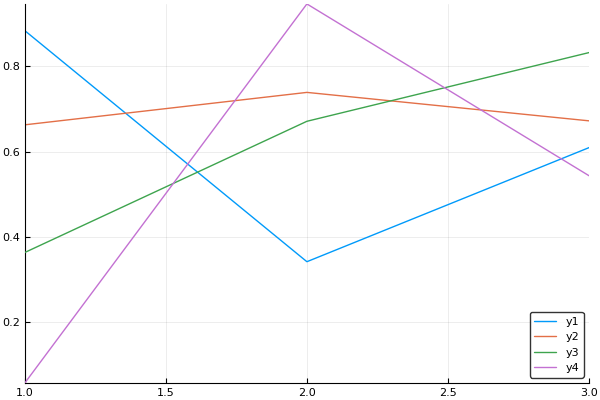

```julia
plot(rand(3,4))
```

```julia
names(df)
```

```
6-element Array{Symbol,1}:
 :Rank
 :Discipline
 :YrsSincePhD
 :YrsService
 :Sex
 :Salary
```

```julia
Pkg.add("StatPlots")
using StatPlots
```

```
INFO: Package StatPlots is already installed
INFO: METADATA is out-of-date — you may not have the latest version of StatPlots
INFO: Use `Pkg.update()` to get the latest versions of your packages
```

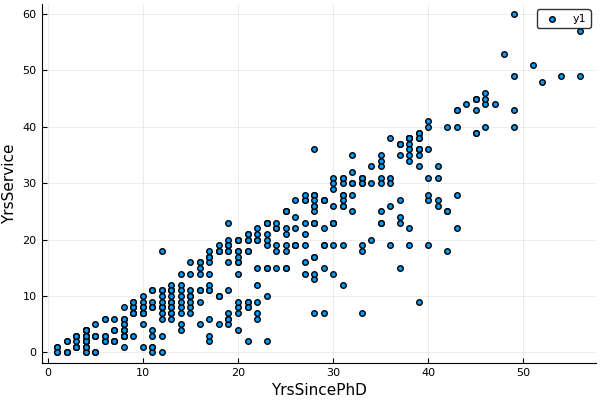

```julia
scatter(df, :YrsSincePhD, :YrsService)
```

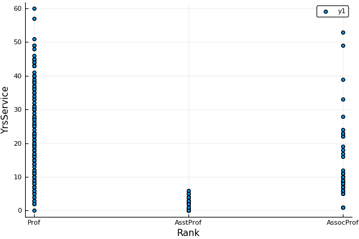

```julia
scatter(df, :Rank, :YrsService)
```

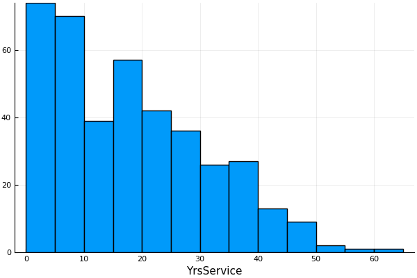

```julia
histogram(df, :YrsService, leg=false)
```

```julia
plotlyjs()
counts = by(df, :Rank, g -> DataFrame(count = size(g,1)))
pie(counts[:Rank], counts[:count], axis=false)
```

[interactive chart not shown]

```julia
counts = by(df, :Discipline, g -> DataFrame(count = size(g,1)))
bar(counts[:Discipline], counts[:count], label="Discipline")
```

[interactive chart not shown]

```julia
boxplot(["YrsService" "YrsSincePhD"], [df[:YrsService], df[:YrsSincePhD]], leg=false)
```

[interactive chart not shown]

```julia
series = [@where(df, :Sex.== "Male")[:Salary],
          @where(df, :Sex.== "Female")[:Salary]]
boxplot(["Male" "Female"], series, leg=false)
```

[interactive chart not shown]

# A solution for the 0-1 Knapsack Problem using genetic algorithms

Based on an example from http://www.dataminingapps.com/2017/03/solving-the-knapsack-problem-with-a-simple-genetic-algorithm/

```julia
using DataFrames
```

```julia
items = DataFrame(profit = [6, 5, 8, 9, 6, 7, 3], weight = [2, 3, 6, 7, 5, 9, 4])
```

|  | profit | weight |
| --- | --- | --- |
| 1 | 6 | 2 |
| 2 | 5 | 3 |
| 3 | 8 | 6 |
| 4 | 9 | 7 |
| 5 | 6 | 5 |
| 6 | 7 | 9 |
| 7 | 3 | 4 |

```julia
MAX_WEIGHT = 9
```

```
9
```

```julia
module GenAlg
using DataFrames

abstract type CrossOverMethod end
struct UniformCrossOver <: CrossOverMethod end
struct OnePointCrossOver <: CrossOverMethod end
struct TwoPointCrossOver <: CrossOverMethod end

abstract type SelectionMethod end
struct RouletteSelection <: SelectionMethod end
struct TournamentSelection <: SelectionMethod
    size::Int
end

mutable struct GenAlgConf
    maxGen::Int
    populationSize::Int
    nDims::Int
    nValues::Int
    crossoverProb::Float64
    mutationProb::Float64
    crossoverMethod::CrossOverMethod
    selectionMethod::SelectionMethod
    useElitism::Bool
    fitnessFunction::Function
end

#type aliases, to make code more readable. They have no performance penalty.
const Individual = Vector{Float64}
const Population = Matrix{Float64}
const PopFitness = Vector{Float64}

function initPopulation(conf::GenAlgConf)::Population
    floor.(rand(conf.populationSize, conf.nDims) * conf.nValues)
end

function selectParents(conf::GenAlgConf, pop::Population, popFitness::Vector{Float64},
        selectionMethod::RouletteSelection) :: Tuple{Int, Int}
    function getParentIndex(probs::Vector{Float64})::Int
        toss = rand()
        parent = 1
        accProb = probs[parent]
        while (parent < size(probs,1) && accProb < toss)
            parent += 1
            accProb += probs[parent]
        end
        parent
    end
    probs = popFitness ./ sum(popFitness)
    parent1 = getParentIndex(probs)
    probs[parent1] = 0 #prevent it from being chosen again
    parent2 = getParentIndex(probs)
    (parent1, parent2)
end

function selectParents(conf::GenAlgConf, pop::Population, popFitness::Vector{Float64},
        selectionMethod::TournamentSelection) :: Tuple{Int, Int}
    contestants = randperm(conf.populationSize)[1:selectionMethod.size]
    (parent1, _) = selectParents(conf, pop[contestants,:], popFitness[contestants], RouletteSelection())
    contestants = randperm(conf.populationSize)[1:selectionMethod.size]
    (parent2, _) = selectParents(conf, pop[contestants,:], popFitness[contestants], RouletteSelection())
    (parent1, parent2)
end

function mutate!(individual::Individual, conf::GenAlgConf)
    for i in 1:conf.nDims
        if rand() < conf.mutationProb
            individual[i] = floor(rand() * conf.nValues)
        end
    end
end

function crossover(conf::GenAlgConf, parent1::Individual, parent2::Individual,
        crossOverMethod::UniformCrossOver) :: Tuple{Individual, Individual}
    (child1, child2) = (similar(parent1), similar(parent2))
    for i in 1:conf.nDims
        if rand() < conf.crossoverProb
            child1[i] = parent2[i]
            child2[i] = parent1[i]
        else
            child1[i] = parent1[i]
            child2[i] = parent2[i]
        end
    end
    mutate!(child1, conf)
    mutate!(child2, conf)
    (child1, child2)
end

function crossover(conf::GenAlgConf, parent1::Individual, parent2::Individual,
        crossOverMethod::OnePointCrossOver) :: Tuple{Individual, Individual}
    (child1, child2) = (similar(parent1), similar(parent2))
    if rand() < conf.crossoverProb
        # second halves are swapped
        cutPoint = floor(Int, rand() * (conf.nDims - 1))
        child1[1:cutPoint] = parent1[1:cutPoint]
        child2[1:cutPoint] = parent2[1:cutPoint]
        child1[cutPoint+1:end] = parent2[cutPoint+1:end]
        child2[cutPoint+1:end] = parent1[cutPoint+1:end]
    else
        #no crossover, children are copies of the parents
        child1[:] = parent1[:]
        child2[:] = parent2[:]
    end
    mutate!(child1, conf)
    mutate!(child2, conf)
    (child1, child2)
end

function crossover(conf::GenAlgConf, parent1::Individual, parent2::Individual,
        crossOverMethod::TwoPointCrossOver) :: Tuple{Individual, Individual}
    (child1, child2) = (similar(parent1), similar(parent2))
    cutPoints = sort(randperm(conf.nDims - 1)[1:2])
    if rand() < conf.crossoverProb
        # middle halves are swapped
        child1[1:cutPoints[1]] = parent1[1:cutPoints[1]]
        child1[cutPoints[1]+1:cutPoints[2]] = parent2[cutPoints[1]+1:cutPoints[2]]
        child1[cutPoints[2]+1:end] = parent1[cutPoints[2]+1:end]
        child2[1:cutPoints[1]] = parent2[1:cutPoints[1]]
        child2[cutPoints[1]+1:cutPoints[2]] = parent1[cutPoints[1]+1:cutPoints[2]]
        child2[cutPoints[2]+1:end] = parent2[cutPoints[2]+1:end]
    else
        #no crossover, children are copies of the parents
        child1[:] = parent1[:]
        child2[:] = parent2[:]
    end
    mutate!(child1, conf)
    mutate!(child2, conf)
    (child1, child2)
end

# it is a convention that in-place functions end with "!"
function makeNewPopulation!(conf::GenAlgConf, pop::Population,
        popFitness::Vector{Float64}, newPop::Population)
    for i in 1:2:conf.populationSize
        (parent1, parent2) = selectParents(conf, pop, popFitness, conf.selectionMethod)
        (newPop[i, :], newPop[i + 1, :]) =
            crossover(conf, pop[parent1,:], pop[parent2,:], conf.crossoverMethod)
    end
end

function run(conf::GenAlgConf)::Tuple{Population, Individual}
    pop = initPopulation(conf)
    popFitness = conf.fitnessFunction(pop)
    newPop = similar(pop)
    newPopFitness = similar(popFitness)
    bestIndividual = zeros(conf.nDims)
    bestFitness = 0.0
    bestOldIndex = indmax(popFitness)
    for gen in 1:conf.maxGen
        if popFitness[bestOldIndex] > bestFitness
            bestFitness = popFitness[bestOldIndex]
            bestIndividual[:] = pop[bestOldIndex, :]
        end
        makeNewPopulation!(conf, pop, popFitness, newPop)
        newPopFitness[:] = conf.fitnessFunction(newPop)
        if conf.useElitism
            worstNewIndex = indmin(newPopFitness)
            newPopFitness[worstNewIndex] = popFitness[bestOldIndex]
            newPop[worstNewIndex, :] = pop[bestOldIndex, :]
        end
        pop[:] = newPop[:]
        popFitness[:] = newPopFitness[:]
        bestOldIndex = indmax(popFitness)
    end
    (newPop, bestIndividual)
end

end #module
```

```
GenAlg
```

```julia
function getFitnessFunc(items::DataFrame, maxWeight::Int) ::Function
     function fitnessFunc(pop::GenAlg.Population) :: Vector{Float64}
            profit::Vector{Float64} = pop * convert(Vector{Float64}, items[:profit])
            weight::Vector{Float64} = pop * convert(Vector{Float64}, items[:weight])
            (profit ./ (abs.(weight - maxWeight) + eps()))
        end
    return fitnessFunc
end
```

```
getFitnessFunc (generic function with 1 method)
```

```julia
MAX_GEN = 100
POP_SIZE = 100
N_DIMS = size(items, 1)
N_VALUES = 2 # binary coding
P_CROSS = 0.8
P_MUT = 0.001
USE_ELITISM = true
CROSSOVER = GenAlg.UniformCrossOver()
#CROSSOVER = GenAlg.OnePointCrossOver()
#CROSSOVER = GenAlg.TwoPointCrossOver()
SELECTION = GenAlg.RouletteSelection()
#SELECTION = GenAlg.TournamentSelection(5)
fitness = getFitnessFunc(items, MAX_WEIGHT)
```

```
(::fitnessFunc) (generic function with 1 method)
```

```julia
@code_warntype(fitness(rand(10, size(items, 1))))
```

[output not shown]

[output cut: 264 more lines]

```
      262:  # line 79:
      264:
      goto 218
      266:
      # meta: pop location
      # meta: pop location
      # meta: pop location
      # meta: pop location
      goto 273 # line 319:
      273:
      # meta: pop location
      # meta: pop location
      $(Expr(:inbounds, :pop))
      return C@_42::Array{Float64,1}
  end::Array{Float64,1}
```

```julia
conf = GenAlg.GenAlgConf(MAX_GEN, POP_SIZE, N_DIMS, N_VALUES, P_CROSS, P_MUT,
    CROSSOVER, SELECTION, USE_ELITISM, fitness)
```

```
GenAlg.GenAlgConf(100, 100, 7, 2, 0.8, 0.001, GenAlg.UniformCrossOver(), GenAlg.RouletteSelection(), true, fitnessFunc)
```

```julia
(newPopulation, bestIndividual) = GenAlg.run(conf)
```

```
([1.0 0.0 … 0.0 0.0; 1.0 0.0 … 0.0 0.0; … ; 1.0 0.0 … 0.0 0.0; 1.0 0.0 … 0.0 0.0], [1.0, 0.0, 0.0, 1.0, 0.0, 0.0, 0.0])
```

```julia
newFitness = conf.fitnessFunction(newPopulation)
```

```
100-element Array{Float64,1}:
 6.7554e16
 6.7554e16
 6.7554e16
 6.7554e16
 6.7554e16
 6.7554e16
 6.7554e16
 6.7554e16
 6.7554e16
 6.7554e16
 6.7554e16
 6.7554e16
 6.7554e16
 ⋮
 6.7554e16
 6.7554e16
 6.7554e16
 6.7554e16
 6.7554e16
 6.7554e16
 6.7554e16
 6.7554e16
 6.7554e16
 6.7554e16
 6.7554e16
 6.7554e16
```

```julia
mean(newFitness)
```

```
6.755399441055744e16
```

```julia
minimum(newFitness)
```

```
6.755399441055744e16
```

```julia
maximum(newFitness)
```

```
6.755399441055744e16
```

```julia
bestIndividual
```

```
7-element Array{Float64,1}:
 1.0
 0.0
 0.0
 1.0
 0.0
 0.0
 0.0
```

```julia
bestIndividual' * items[:profit]
```

```
15.0
```

## Links:

https://julialang.org/

Tutorials:  
http://ucidatascienceinitiative.github.io/IntroToJulia/  
https://github.com/scidom/StatsLearningByExample.jl  
http://www.breloff.com/JuliaML-and-Plots/  
https://lectures.quantecon.org/jl/julia_plots.html#plotsjl-jl  
https://en.wikibooks.org/wiki/Introducing_Julia/Plotting

Articles:  
http://ucidatascienceinitiative.github.io/IntroToJulia/Html/WhyJulia  
http://www.stochasticlifestyle.com/7-julia-gotchas-handle/  
https://arstechnica.com/science/2014/05/scientific-computings-future-can-any-coding-language-top-a-1950s-behemoth/  
http://www.admin-magazine.com/HPC/Articles/Julia-A-New-Language-For-Technical-Computing  
http://www.admin-magazine.com/HPC/Articles/Parallel-Julia-Jumping-Right-In  
https://www.evanmiller.org/why-im-betting-on-julia.html